# Analysis of E-Commerce Data using Hadoop Ecosystem

## Introduction:

In the last few years, with the advancement of technologies and digitization, the amount of data generated rapidly increased from Terabytes to Zettabytes and by 2025, it is predicted there would a big and tremendous volume of data collections and that would be nearly 163 zettabytes. To handle this huge volume of data and process them to draw meaningful insights technologies like Hadoop and its ecosystem come to rescue.

To explore on big data technologies – Hadoop and its ecosystem, we opted to work on e-commerce data (Best Buy store website).Data collected includes information on products such as Cell phones, Desktops and Laptops. We aim to store and analyse this data to draw useful insights such as compare price of different cell phones along with the carrier. On the same lines, compare cost of laptops across different brands. Customer top rated products and so on.

## Pipeline to analyse e-commerce data using Hadoop Ecosystem

The main goal of this project is to have a pipeline that leverages the functionalities of hadoop ecosystem and can handle near-real time data to draw insights helpful for drawing Business decisions.

The pipeline was implemented on Google Compute Engine. Hortonworks Data Platform- 2.6 was installed on two nodes(each 8vCPU's, 32GB RAM).

[figure not shown]

## Implementation

### Data Acquistion:

To get the glimpse of data acquired, columns that provide significant information about the products is shown in below table along with it's description.

| Column Name | Description |
| --- | --- |
| productId | Unique identifier of product |
| description | Description of the product |
| regularPrice | Off Sale price |
| onSale | On Sale - True or False |
| salePrice | On sale price |
| contracts | Phone contract carrier name |
| carrierPlans | Carrier plan details |
| earlyTerminationFees | Termination of contract charges |
| activationCharge | Plan activation charges |
| customerReviewCount | reviews by customers |
| customerReviewAverage | Average review rating(out of 5) |
| onlineAvailability | Item available online to shop(True or False) |
| shippingCost | charges for shipping item |
| manufacturer | Brand name |
| screenSizeIn | Screen size in inches |
| color | Color of the product |
| releaseDate | Official release date of the product |
| inStoreAvailability | Availablility in store |
| warranty | Warranty term information |

### Data Ingestion

In the real-time, data acquired from the sources is typically huge and having an intermediate component which can receive continuous flow of data, store until the data is safely delivered to the target system. Apache Flume is one such component in the Hadoop ecosystem which was developed by Cloudera to provide a way to quickly stream large volumes of log or event data generated by web servers into HDFS(Data lake, discussed in next section).Flume has a simple and flexible architecture based on streaming data flows. It is robust and fault tolerant with tuneable reliability mechanisms and many failover and recovery mechanisms. It uses a simple extensible data model that allows for online analytic application. Because of these functionalities and our goal is to analyze e-commerce data, Apache Flume was chosen.

Apache Flume has an agent that consists of Source, channel and sink. Source is responsible to receive data from the webservers. In our case, source listens to the data from Best buy REST API(code that makes API call to fetch the data and send to the source is available in Appendix section of this document) on port 5140. When the data is available on source, data is sent to "Memory channel" that has memory allocated enough to hold the data until it is read by Sink. Sink then reads data from the channel and puts on the target specified(HDFS : /user/flume/BestBuyData/ in our case). Below is the configuration for the flume.

```
#Source
bbagent.sources=restdata
bbagent.sources.restdata.channels=memoryChannel
bbagent.sources.restdata.handler=org.apache.flume.sink.solr.morphline.JSONHandler
bbagent.sources.restdata.port=5140
bbagent.sources.restdata.type=http

#Memory Channel
bbagent.channels=memoryChannel
bbagent.channels.memoryChannel.capacity=100000
bbagent.channels.memoryChannel.transactionCapacity=100
bbagent.channels.memoryChannel.type=memory

#Sink
bbagent.sinks=tohdfs
bbagent.sinks.tohdfs.channel=memoryChannel
bbagent.sinks.tohdfs.hdfs.filePrefix=products-
bbagent.sinks.tohdfs.hdfs.fileType=DataStream
bbagent.sinks.tohdfs.hdfs.path=/user/flume/BestBuyData/
bbagent.sinks.tohdfs.hdfs.writeFormat=Text
bbagent.sinks.tohdfs.type=hdfs
```

The picture below shows the small peaks in the metrics for Incoming and Outgoing events data through the Apache Flume agent components. The data from Best buy REST API is sent to Flume which is then put on Hadoop Distributed Filesystem by agent.

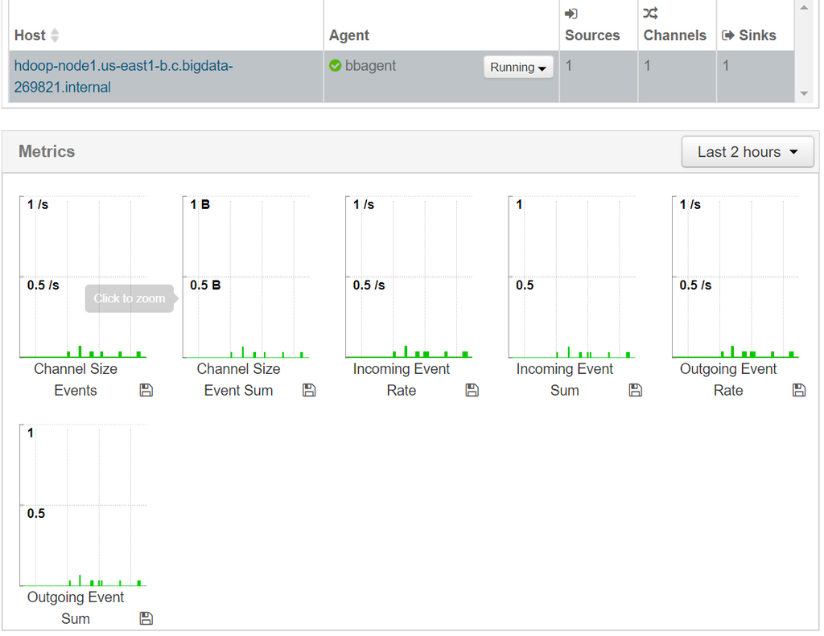

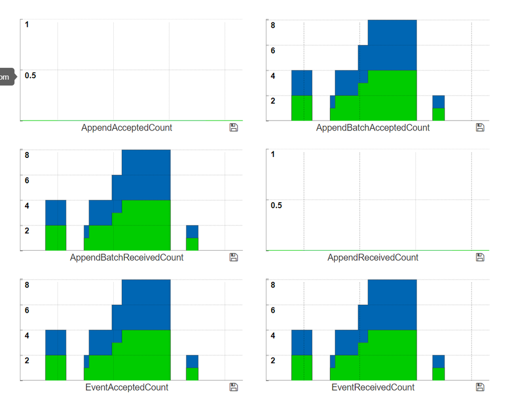

The logs also show the files being created on HDFS - /user/flume/BestBuyData/, prefixing products to the file names when the data stream is available to Flume. The point to be noted here is the JSON object handler "org.apache.flume.sink.solr.morphline.JSONHandler". Since the data extracted from the website using is of JSON type, we are explicitly indicating that event is in JSON format (UTF-8-character set) so that it can be handled by Flume.

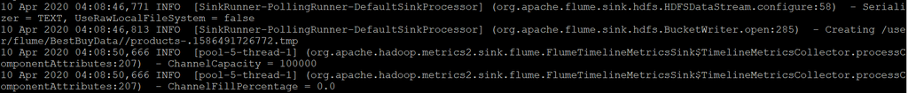

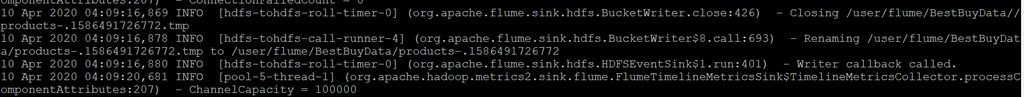

### Data Lake

Hadoop Distributed Filesystem is designed to run on commodity hardware, high fault tolerant and offer high throughput to application data. HDFS is suitable for applications that have large data sets and acts as a repository for analytics data. Goal of the project is to build data lake on HDFS. Build was two compute nodes(Google compute engines) cluster whose storage representing distributed file system on both the nodes.Our data lake comprised of files that holds JSON objects, which is the near real-time data acquired from the Best buy e-commerce website.

Below image shows the files of Best buy website products data put by Flume on HDFS.

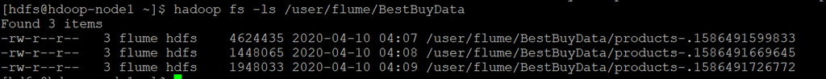

### Understand data using NoSQL Database:

It is crucial to understand data acquired using some tool before it can be transformed and analysed. Since the data acquired is of JSON objects and is highly unstructured data "MongoDB" was chosen to store the data and understand the basic structure of the data. MongoDB is a document-oriented NoSQL database used for high volume data storage. Data acquired and stored on HDFS was loaded on to MongoDB, one collection for each type of product i.e. One collection for cell phone , one for Desktops and one for Laptops.To accomplish this task , mongoimport tool which is part of MongoDB tool packages was used to import JSON data into MongoDB.

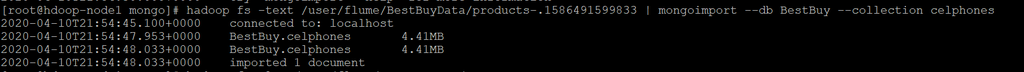

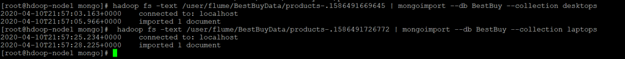

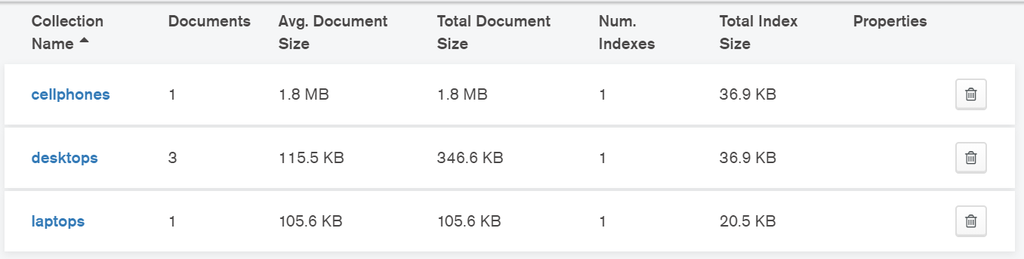

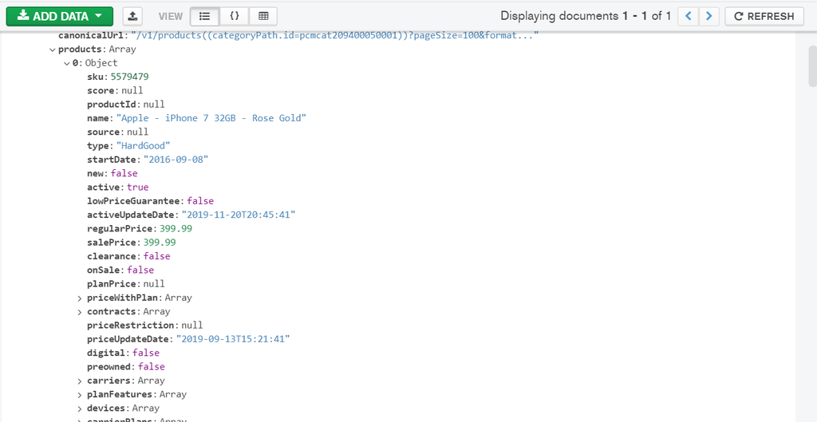

### Extract and Transformation

In order to analyse any data, pre-processing plays an important role. Apache Spark is a unified analytics engine for large-scale data pre-processing. Apache spark provides high-level API's in Java, Scala, R and Python. PySpark is one such API that can collaborate with Apache Spark. To achieve processing and transformation of data acquired, we use PySpark to interact with Spark which enables us to read the data from the MongoDB into Spark's abstraction called Resilient Distributed Dataset (RDD).In order to proceed with it, we need to have "mongo-spark-connector" that acts as the bridge for the access of data between MongoDB and Hadoop. Along with the connector we also need jar files.

**NOTE** : Code for the below explanation is available in Appendix of this document.

The pyspark session is initiated with the by specifying the Jars and packages required to access data from MongoDB. It is also important to use the right version of packages that is compatible with version of database and Apache Spark. In our project , version of spark was 2.2.0, MongoDB was 3.2.22.

Once the data from the MongoDB is read into the Spark's abstraction RDD, one can view the structure of the data. In our case, the data read was complex nested structures with lot of nested struct and array types. In short, struct type is a built-in data type that is a collection of Struct Fields. Struct Type is used to define a schema or its part. Querying and processing such nested schema are usually complicated and tedious tasks. We used "Explode" function as the first level to convert array of struct into array of struct with rows and struct columns and flattened all the struct types in our schema to obtain a single level from the nested level. Spark of version greater than 2.4.0 has python package called "sparkaid" to facilitate the flattening of nested schemas, since we were using lower version of Spark 2.2.0, we had written a user defined function that helped to remove the complex structure from the schema. After the schema was flattened, total 4269 rows and 169 columns were generated.

Below screenshot shows the nested schema after importing data from MongoDB

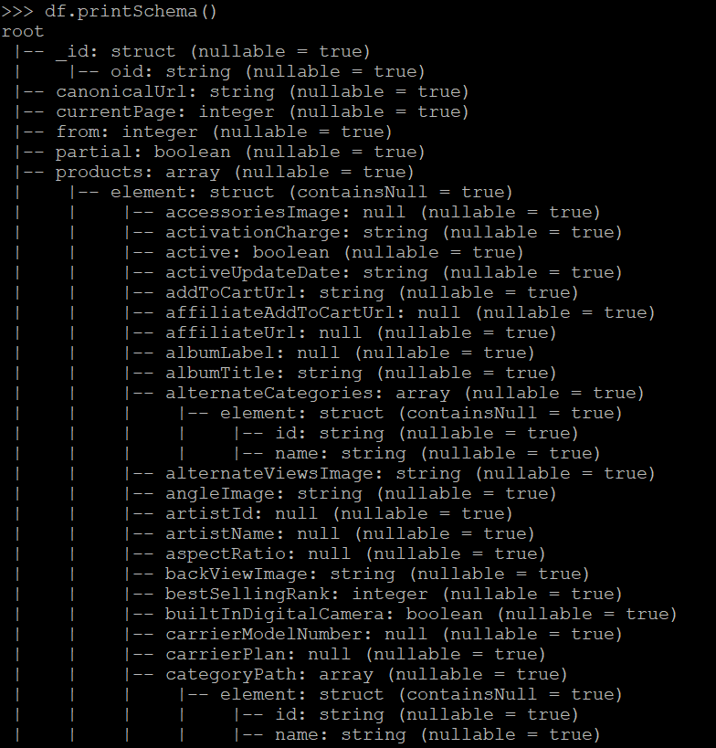

Explode to convert array of struct into array of struct with rows and struct columns.

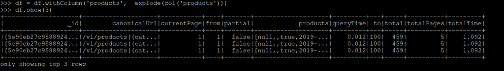

Flattening of the schema using user defined function

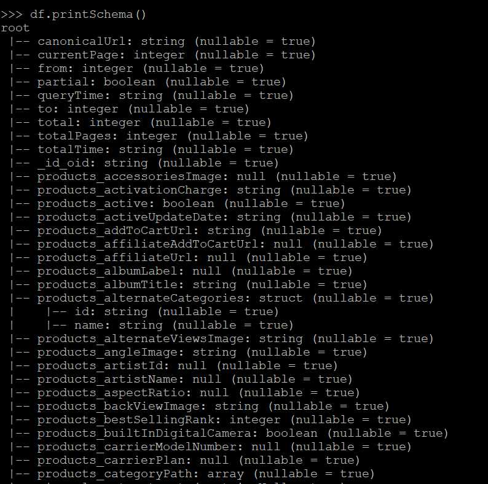

Now that schema is flattened and it's easy to query dataframe. Data can be inspected by querying required fileds in the dataset.Let's view first five rows of fields representing name of the product,it's sale price, online availability and price for shipping the product.

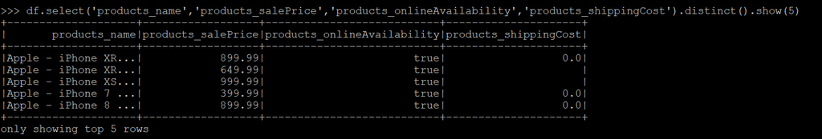

Let's fetch the distinct average customer rating for all the cell phones in our dataset. From the output of the query, we can see all the cell phones in our dataset has average rating of 4.7 or 4.8 out of 5. The screenshot also shows the output of distinct number of reviews on cell phones.

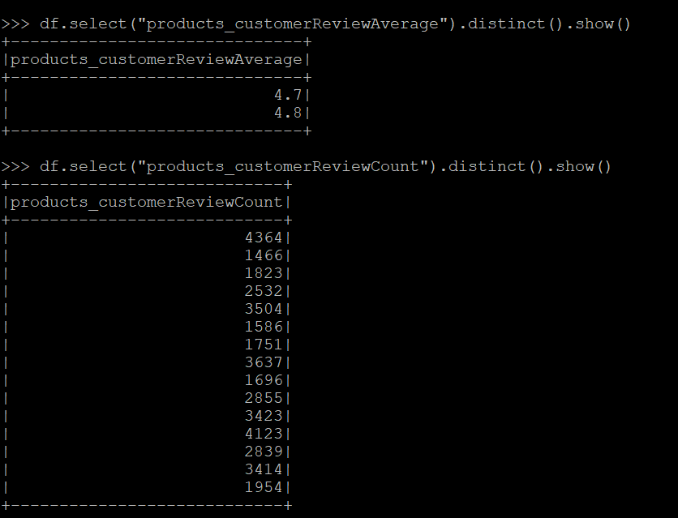

#### Descriptive statistics

PySpark provides us various methods to perform analytics on the data. We can view statitics of the numerical fields by calling describe method on the field.

As we viewed the unique values of average review rating on the cellphones above, below image shows minimum and maximum values of the field.

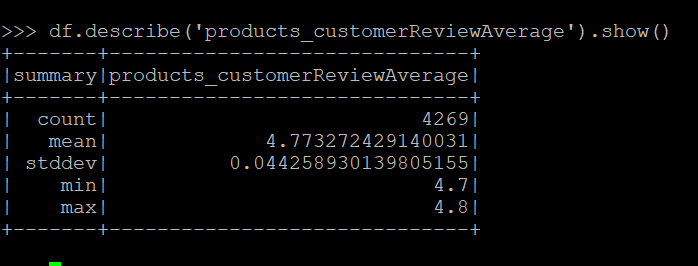

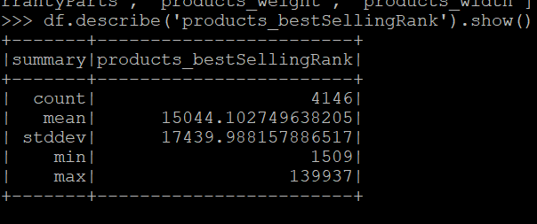

[output not shown]

### Load into Datawarehouse

The Apache Hive data warehouse software facilitates reading, writing, and managing large datasets residing in distributed storage using SQL. Structure can be projected onto data already in storage.We use Apache hive to store the data transformed using Apache Spark, so that it can be easily queries using HiveQL which is same as Structured Query Language(SQL). Hive also provides us the web user interface to query and visualize the data.

Data from the Spark is inserted into Hive tables for further analysis. The choice of storing data onto Hive tables is because of the functionality provided by Hive as stated above and ease of querying the data and access of the Hive tables through visualization tools such as Apache Zeppelin(discussed in next section).

Below screenshots shows the table created on Hive datawareshouse through PySpark with data of average price of cell phone grouped by model name.

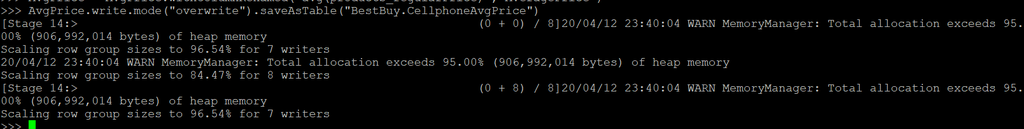

Now that table is created, we can verify the table on Amabri console by navigating to the "Hive view" and also query the data using HiveQL to view the data residing in the table.

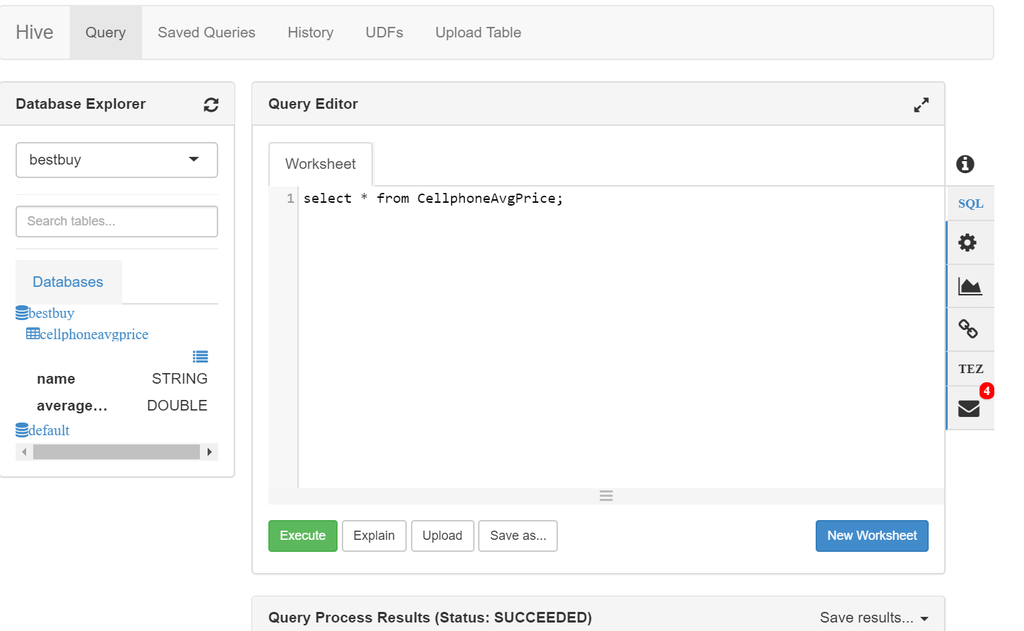

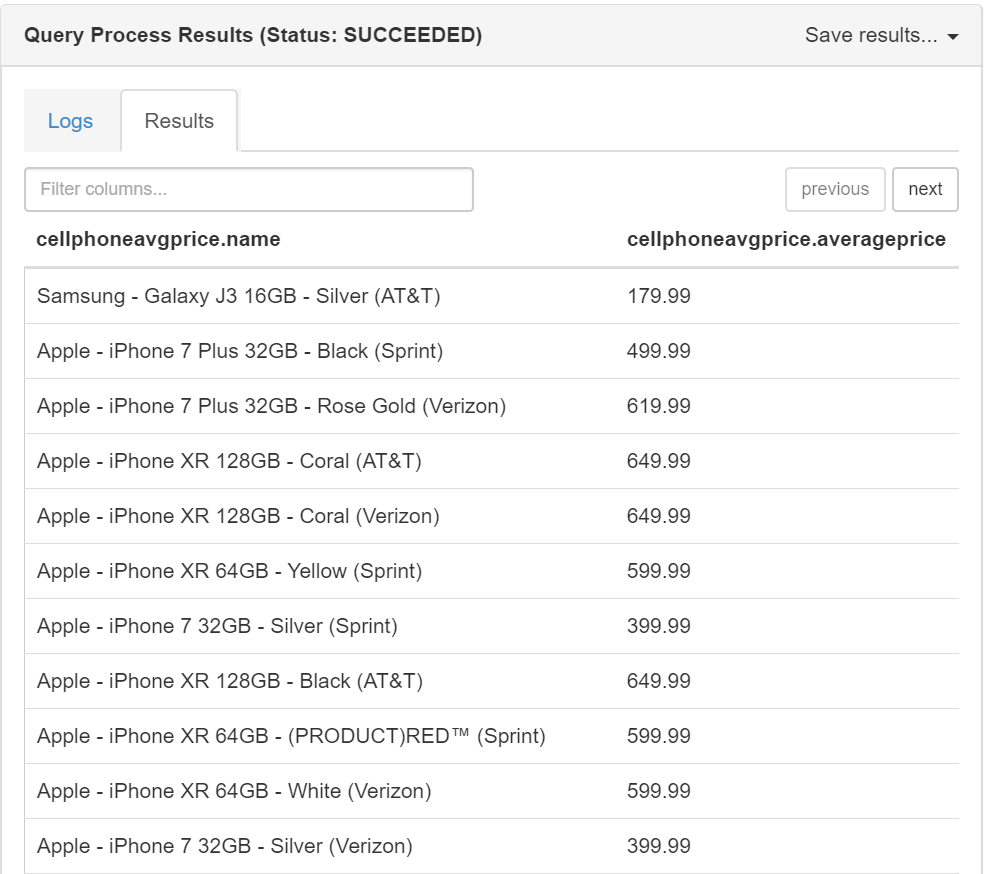

### Visualization

Apache Zeppelin is completely open web-based notebook that enables interactive data analytics.Apache Zeppelin is a new and incubating multi-purposed web-based notebook which brings data ingestion, data exploration, visualization, sharing and collaboration features to Hadoop and Spark.Zeppelin provides a “Modern Data Science Studio” that supports Spark and Hive out of the box. We opted to use Appache Zeppelin to explore data transformed through Spark and visualize.We used Apache Zeppelin JDBC interpreter to access Apache Hive tables.The interpreter connects to Hive via Thrift.

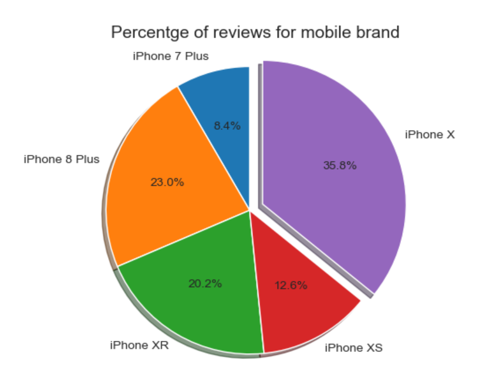

Below bar graph shows the prices for selected iPhone along with their model and carriers. It is eveident that iPhone is XS with 512G and AT&T carrier is the costliest while Samsung Galaxy J3 is the cheapest. Looking at the above analysis we might assume that people didn't rate much on iPhone XS may be because it's costly and not everyone can afford for.

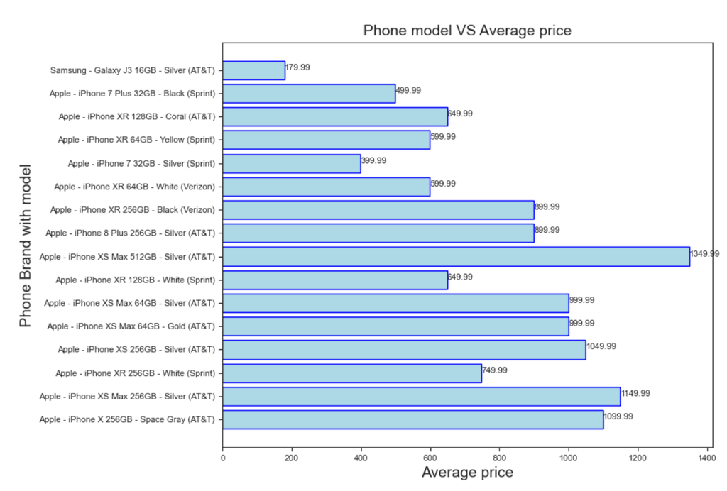

Below graph is an attempt to see the difference between screen size of laptops from various brands in the market.Google brand laptops are of 12.30 inches screen size which is compact version of others while Asus laptops come with 14.25 inches screen.

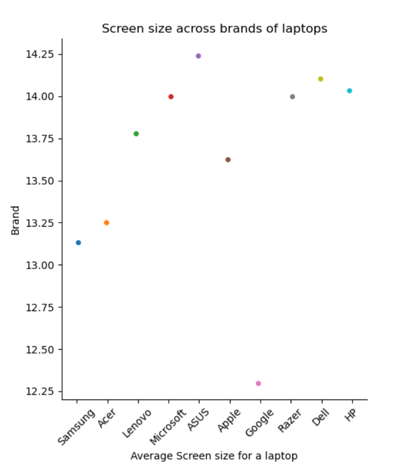

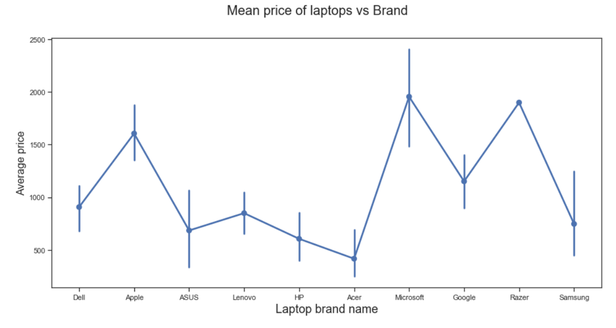

## Appendix

1.Python code used to make API calls to the website to acquire the data

```
import requests
import os
import json

def extract_data(product):
    response = requests.get(product)
    response_dict = json.loads(response.text)
    response_str = json.dumps(response_dict,sort_keys=True, indent=4)
    return response_str

#Fetch details of products from REST API
celphones = "https://api.bestbuy.com/v1/products((categoryPath.id=pcmcat209400050001))?apiKey=qn3zdqzs23x2njxfv6zx&pageSize=100&format=json"
computers = "https://api.bestbuy.com/v1/products((categoryPath.id=abcat0501000))?apiKey=qn3zdqzs223x2njxfv6zx&pageSize=100&format=json"
laptops = "https://api.bestbuy.com/v1/products((categoryPath.id=abcat0502000))?apiKey=qn3zdqzs23x2njxfv6zx&pageSize=100&format=json"

#Define URL for Flume to send data
flume_url = 'http://0.0.0.0:5140'

#Function call for cellphones
celphone_str = extract_data(celphones)
requests.post(flume_url, data=celphone_str)

#Function call for Desktops
computers_str = extract_data(computers)
requests.post(flume_url, data=computers_str)

#Function call for Desktops
laptops_str = extract_data(laptops)
requests.post(flume_url, data=laptops_str)
```

2.Pyspark code to read data from MongoDB, analyze and store data on Hive tables

```
pyspark --jars "/root/mongo-hadoop-spark-2.0.2.jar"  --driver-class-path "/root/mongo-java-driver-3.4.2.jar" --py-files "/root/mongo-hadoop/spark/src/main/python/pymongo_spark.py" --packages org.mongodb.spark:mongo-spark-connector_2.11:2.2.7

from pyspark import SparkContext,SparkConf
from pyspark.sql import SparkSession,HiveContext
from pyspark.sql.functions import col,explode

conf = SparkConf().set("spark.jars.packages","org.mongodb.spark:mongo-spark-connector_2.11:2.2.7")


spark = SparkSession\
.builder.\
appName("BestBuySpark")\
.config("spark.mongodb.input.uri", "mongodb://127.0.0.1/BestBuy.celphones")\
.config("spark.sql.warehouse.dir", "/root/spark-warehouse")\
.enableHiveSupport()\
.getOrCreate()

sqlContext = SQLContext(spark.sparkContext)

df = sqlContext.read.format("com.mongodb.spark.sql.DefaultSource").option("uri","mongodb://localhost/BestBuy.celphones").load()

 df.printSchema()


#Explode to convert array of struct into array of struct with rows and struct_columns

def flatten_struct_cols(df):
    flat_cols = [column[0] for column in df.dtypes if 'struct' not in column[1][:6]]
    struct_columns = [column[0] for column in df.dtypes if 'struct' in column[1][:6]]
    df = df.select(flat_cols +
                   [col(sc + '.' + c).alias(sc + '_' + c)
                   for sc in struct_columns
                   for c in df.select(sc + '.*').columns])
    return df

df = df.withColumn('products', explode(col('products')))
df = flatten_struct_cols(df)
df.printSchema()

#Create table from DataFrame

df.registerTempTable('celphone_table')
sqlContext.sql('select * from celphone_table').show()

#Database on Hive
spark.sql("create database BestBuy")
DataFrame[]

sqlContext.sql("create table BestBuy.Cellphones as select  from celphone_table");


#Average cost of a celphone
AvgPrice = df.groupby("products_name").avg("products_regularPrice").collect()
type(AvgPrice)
AvgPrice = spark.createDataFrame(AvgPrice)
type(AvgPrice)
AvgPrice.registerTempTable('CellphoneAvgPrice')
AvgPrice = AvgPrice.withColumnRenamed("products_name","Name")
AvgPrice = AvgPrice.withColumnRenamed("avg(products_regularPrice)","AveragePrice")
AvgPrice.write.mode("overwrite").saveAsTable("BestBuy.CellphoneAvgPrice")

#Total review count for each celphone
reviewcount = sorted(df.groupBy(['products_name', df.products_customerReviewCount]).count().collect())
reviewcount = spark.createDataFrame(reviewcount)
reviewcount.write.mode("overwrite").saveAsTable("BestBuy.CellphoneReviewCount")
sqlContext.sql('select *  from CellphonesReviewCount').show()


#Data for laptops
laptops = sqlContext.read.format("com.mongodb.spark.sql.DefaultSource").option("uri","mongodb://localhost/BestBuy.laptops").load()
laptops = laptops.withColumn('products', explode(col('products')))
laptops = flatten_struct_cols(laptops)
AvgScreenSize = laptops.groupby("products_manufacturer").avg("products_screenSizeIn").collect()
AvgScreenSize = spark.createDataFrame(AvgScreenSize)
AvgScreenSize.registerTempTable('AvgScreenSize')
sqlContext.sql('select * from AvgScreenSize').show()
AvgScreenSize = AvgScreenSize.withColumnRenamed("products_manufacturer","manufacturer")
AvgScreenSize = AvgScreenSize.withColumnRenamed("avg(products_screenSizeIn)","AverageScreenSizeInches")
AvgScreenSize.write.mode("overwrite").saveAsTable("BestBuy.AvgScreenSize")

#Desktops
desktops = sqlContext.read.format("com.mongodb.spark.sql.DefaultSource").option("uri","mongodb://localhost/BestBuy.desktops").load()
desktops = desktops.withColumn('products', explode(col('products')))
desktops = flatten_struct_cols(desktops)
MinSalePrice = laptops.groupby("products_modelNumber","products_manufacturer").min("products_salePrice").collect()
MinSalePrice = spark.createDataFrame(MinSalePrice)
MinSalePrice.registerTempTable('MinSalePrice')
sqlContext.sql('select * from MinSalePrice').show()
MinSalePrice = MinSalePrice.withColumnRenamed("min(products_salePrice)","MinSalePrice")
MinSalePrice.write.mode("overwrite").saveAsTable("BestBuy.MinSalePrice")
```

3.Code for Zeppelin

```
%jdbc(hive)
show databases;
use default;
show tables;
select * from MinSalePrice limit 10;


%spark2
val sqlContext = new org.apache.spark.sql.hive.HiveContext(sc)
val tables = sqlContext.sql("show tables")
tables.show(2)
val df_cellavgprice = sqlContext.sql("SELECT * from covid19")
val cellavgprice = sqlContext.sql("SELECT name, AveragePrice from cellavgprice").show()
cellavgprice.show()
#for using the dataframe in pyspark
z.put("df", cellavgprice: org.apache.spark.sql.DataFrame)

%spark2.pyspark
print(z["xtable"])
import numpy as np
import pandas as pd

import matplotlib.pyplot as plt
import seaborn as sns

df = sqlContext.table("cellavgprice").select()
df.printSchema
pdf = df.toPandas()
print(pdf)

import pandas
from pyspark.sql import DataFrame
df = DataFrame(z.get("df"), sqlContext)
cellavgprice_final = df.toPandas()

covid19_final.replace('NaN',0)

#Query1
%hive
import matplotlib.pyplot as plt
import seaborn as sns
sns.set_style("ticks")
plt.figure(figsize = (15,10))
plt.barh(cellphoneavgprice["cellphoneavgprice.name"], cellphoneavgprice["cellphoneavgprice.averageprice"].map(int), align = 'center', color = 'lightblue', edgecolor = 'blue')
plt.ylabel('Phone Brand with model', fontsize = 14)
plt.xlabel('Average price', fontsize = 14)
plt.gca().invert_yaxis()
plt.xticks(fontsize = 8)
plt.yticks(fontsize = 8)
plt.title('Phone model VS Average price', fontsize = 14 )
for index, value in enumerate(cellphoneavgprice["cellphoneavgprice.averageprice"]):
    plt.text(value, index, str(value), fontsize = 8)
plt.show()

#query2:
%hive
ax = sns.catplot(x="avgscreensize.manufacturer",y="avgscreensize.averagescreensizeinches", data=avgscreensize)
plt.xlabel('Average Screen size for a laptop')
ax.set_xticklabels(rotation=45)
plt.ylabel('Brand')
plt.title('Screen size across brands of laptops',y=1.05)
plt.show()


#query 3:
%hive
fig, ax = plt.subplots(figsize=(15,7))
ax = sns.pointplot(minsaleprice['minsaleprice.products_manufacturer'],minsaleprice['minsaleprice.minsaleprice'], data =minsaleprice )
fig.suptitle('Mean price of laptops vs Brand', fontsize=20)
plt.xlabel('Laptop brand name', fontsize=18)
plt.ylabel('Average price', fontsize=16)
plt.show()

#query 4:
%hive
explode = (0, 0, 0, 0, 0.1)

fig1, ax1 = plt.subplots()
ax1.pie(cellphonereviewcount['cellphonereviewcount.products_customerreviewcount'], labels = cellphonereviewcount['cellphonereviewcount.products_name'], explode=explode, autopct='%1.1f%%',
        shadow=True, startangle=90)
ax1.axis('equal')
plt.rc('font', size = 10)
plt.title('Percentge of reviews for mobile brand', fontsize = 14)
plt.show()
```